# Homework_10

Andrew McCracken

3/30/2022

Home Page

#### **1) Using a for loop, write a function to calculate the number of zeroes in a numeric vector. Before entering the loop, set up a counter variable counter <- 0. Inside the loop, add 1 to counter each time you have a zero in the matrix. Finally, use return(counter) for the output.**

```r
library(tidyverse)
library(data.table)
myvec <- c(1,0,3,0,6,0,3,7,2,0,3,5,8,0,33,0,5,2,6,0,0,0,3,4,7,8,5,0,0,6)

##############################
# FUNCTION: loop_for_0_HW10
# purpose: loop through a vector and count the number of zeros
# input: numeric vector
# output: Number of 0 in the vector
# ------------------------------------------

loop_for_0_HW10 <- function(x) {

  counter <- 0

  for (i in 1:length(myvec)) {
    if(myvec[i] == 0) {
      counter <- counter+1 }
  }
  return(c("Number of 0's in your vector = ", counter))
}

loop_for_0_HW10(myvec)
```

```
## [1] "Number of 0's in your vector = " "11"
```

#### **2) Use subsetting instead of a loop to rewrite the function as a single line of code.**

```r
##############################
# FUNCTION: subset_for_0_HW10
# purpose: Subset a vector and count the number of zeros
# input: numeric vector
# output: Number of 0 in the vector
# ------------------------------------------

subset_for_0_HW10 <- function(x) {
  zeros <- subset(x,x[]==0)
  return(length(zeros))
}

subset_for_0_HW10(myvec)
```

```
## [1] 11
```

#### **3) Write a function that takes as input two integers representing the number of rows and columns in a matrix. The output is a matrix of these dimensions in which each element is the product of the row number x the column number.**

```r
##############################
# FUNCTION: matrix
# purpose:
# input: two integers representing the number of rows and columns in a matrix
# output:  matrix of these dimensions in which each element is the product of the row number x the column numbe
# ------------------------------------------
make_matrix <- function(i=5,j=5) {

  mtx <- matrix(, nrow=i, ncol=j)

  for(i in 1:nrow(mtx)) {
    for(j in 1:ncol(mtx)){

      mtx[i,j] <- i*j

    }
  }
  return(mtx)
}
make_matrix()
```

```
##      [,1] [,2] [,3] [,4] [,5]
## [1,]    1    2    3    4    5
## [2,]    2    4    6    8   10
## [3,]    3    6    9   12   15
## [4,]    4    8   12   16   20
## [5,]    5   10   15   20   25
```

### **4)In the next few lectures, you will learn how to do a randomization test on your data. We will complete some of the steps today to practice calling custom functions within a for loop. Use the code from the March 31st lecture (Randomization Tests) to complete the following steps**

#### **A) Simulate a dataset with 3 groups of data, each group drawn from a distribution with a different mean. The final data frame should have 1 column for group and 1 column for the response variable.**

```r
G1 <- rnorm(n=10, mean=5, sd=1)
G2 <- rnorm(n=10, mean=7, sd=1)
G3 <- rnorm(n=10, mean=3, sd=1)

df <- data.frame(G1,G2,G3)
df_long <- pivot_longer(df,cols= 1:3, names_to = "Group", values_to = "Response_Var")
df_long
```

```
## # A tibble: 30 x 2
##    Group Response_Var
##    <chr>        <dbl>
##  1 G1           4.29
##  2 G2           5.98
##  3 G3           2.02
##  4 G1           5.12
##  5 G2           7.14
##  6 G3           0.786
##  7 G1           4.53
##  8 G2           6.03
##  9 G3           2.76
## 10 G1           4.36
## # ... with 20 more rows
```

#### **B)Write a custom function that 1) reshuffles the response variable, and 2) calculates the mean of each group in the reshuffled data. Store the means in a vector of length 3.**

```r
##############################
# FUNCTION: shuffle
# purpose: 1) reshuffles the response variable, and 2) calculates the mean of each group in the reshuffled data. Store the means in a vector of length 3.
# input: Data Frame
# output:
# ------------------------------------------
shuffle <- function(df) {
  df_temp <- df_long

  df_temp$Response_Var_shffle <- sample(df_temp$Response_Var, replace = FALSE)

  setDT(df_temp)
  means <- df_temp[ ,list(mean=mean(Response_Var_shffle)), by=Group]
  means_list <- as.numeric(c(means[1,2],means[2,2],means[3,2]))

  return(means_list)

}

shuffle(df_long)
```

```
## [1] 5.089472 3.364291 6.004078
```

#### **C) Use a for loop to repeat the function in b 100 times. Store the results in a data frame that has 1 column indicating the replicate number and 1 column for each new group mean, for a total of 4 columns.**

```r
df_shuffle_100 <- data.frame(replicate = rep(NA,100),
                      means_G1 = rep(NA,100),
                      mean_G2 = rep(NA,100),
                      mean_G3 = rep(NA,100))

for (i in 1:100) {
  means <- shuffle(df = df_long) # run randomization_test() function

  df_shuffle_100$replicate[i] <- i # fill in replicate column

  df_shuffle_100$means_G1[i] <- means[1]
  df_shuffle_100$mean_G2[i] <- means[2]
  df_shuffle_100$mean_G3[i] <- means[3]

} # end of for loop

head(df_shuffle_100)
```

```
##   replicate means_G1  mean_G2  mean_G3
## 1         1 5.181379 5.266467 4.009994
## 2         2 4.943365 4.762164 4.752312
## 3         3 4.924211 5.123830 4.409800
## 4         4 5.513218 4.386340 4.558283
## 5         5 5.050249 3.662375 5.745217
## 6         6 4.771512 5.232700 4.453629
```

#### **d. Use qplot() to create a histogram of the means for each reshuffled group. Or, if you want a challenge, use ggplot() to overlay all 3 histograms in the same figure. How do the distributions of reshuffled means compare to the original means?**

```r
df_shuffle_100_long <- df_shuffle_100 %>%
  pivot_longer(cols = 2:4,
               names_to = "Group",
               values_to = "means")

head(df_shuffle_100_long,9)
```

```
## # A tibble: 9 x 3
##   replicate Group    means
##       <int> <chr>    <dbl>
## 1         1 means_G1  5.18
## 2         1 mean_G2   5.27
## 3         1 mean_G3   4.01
## 4         2 means_G1  4.94
## 5         2 mean_G2   4.76
## 6         2 mean_G3   4.75
## 7         3 means_G1  4.92
## 8         3 mean_G2   5.12
## 9         3 mean_G3   4.41
```

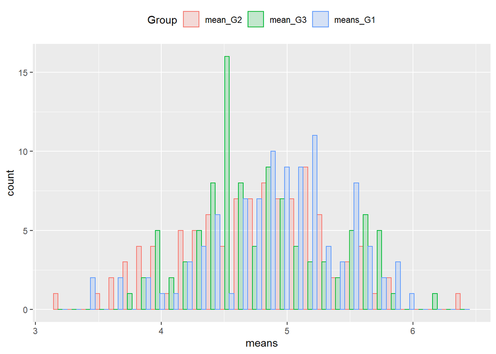

```r
ggplot(data = df_shuffle_100_long,
       aes(x = means, fill = Group, color = Group)) +
  geom_histogram(position = "dodge", alpha = 0.2) +
  theme(legend.position="top")
```

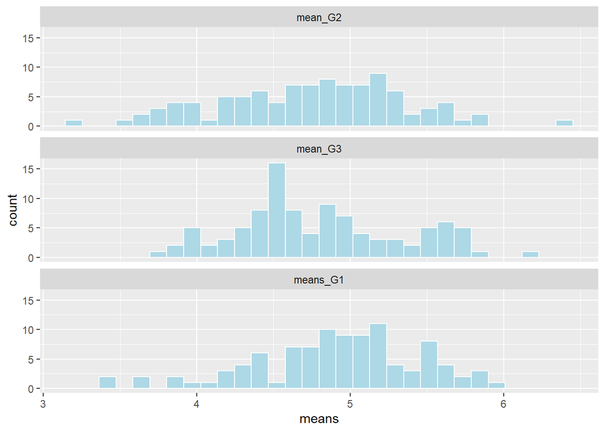

```r
#overlay
ggplot(data = df_shuffle_100_long,
       aes(x = means)) +
  geom_histogram(fill = "lightblue", col = "white", position = "dodge") +
  theme(legend.position="top") +
  facet_wrap(~Group, nrow = 3)
```